# Redución de dimensiones

### Análisis de Componenets Principales

En este documento vamos a utilizar PCA para intentar encontrar las variables (no correlacionadas) que más varianza capturen de la term-document matriz. Utilizaremos datos de cocteles y usaremos como variables los ingredientes.

#### Pre-requisitos:

```r
library(tidyverse)
library(tidytext)
library(tidymodels)
```

#### Datos:

Esta base de datos fue extraida de Mr. Boston Bartender’s Guide. Cuenta con el nombre, ingredientes, tipo de vaso donde se sirven, etc.

```r
cocktails <- readr::read_csv("https://raw.githubusercontent.com/rfordatascience/tidytuesday/master/data/2020/2020-05-26/boston_cocktails.csv")
dim(cocktails)
```

```
## [1] 3643    6
```

```r
names(cocktails)
```

```
## [1] "name"              "category"          "row_id"
## [4] "ingredient_number" "ingredient"        "measure"
```

```r
cocktails %>% head(10)
```

```
## # A tibble: 10 x 6
##    name        category         row_id ingredient_number ingredient      measure
##    <chr>       <chr>             <dbl>             <dbl> <chr>           <chr>
##  1 Gauguin     Cocktail Classi…      1                 1 Light Rum       2 oz
##  2 Gauguin     Cocktail Classi…      1                 2 Passion Fruit … 1 oz
##  3 Gauguin     Cocktail Classi…      1                 3 Lemon Juice     1 oz
##  4 Gauguin     Cocktail Classi…      1                 4 Lime Juice      1 oz
##  5 Fort Laude… Cocktail Classi…      2                 1 Light Rum       1 1/2 …
##  6 Fort Laude… Cocktail Classi…      2                 2 Sweet Vermouth  1/2 oz
##  7 Fort Laude… Cocktail Classi…      2                 3 Juice of Orange 1/4 oz
##  8 Fort Laude… Cocktail Classi…      2                 4 Juice of a Lime 1/4 oz
##  9 Apple Pie   Cordials and Li…      3                 1 Apple schnapps  3 oz
## 10 Apple Pie   Cordials and Li…      3                 2 Cinnamon schna… 1 oz
```

Cada fila representa un ingrediente asociado a una bebida en específico.

```r
cocktails %>%
  count(ingredient, sort = TRUE)
```

```
## # A tibble: 569 x 2
##    ingredient            n
##    <chr>             <int>
##  1 Gin                 176
##  2 Fresh lemon juice   138
##  3 Simple Syrup        115
##  4 Vodka               114
##  5 Light Rum           113
##  6 Dry Vermouth        107
##  7 Fresh Lime Juice    107
##  8 Triple Sec          107
##  9 Powdered Sugar       90
## 10 Grenadine            85
## # … with 559 more rows
```

```r
cocktails %>%
  group_by(measure) %>%
  count(measure,sort = TRUE)
```

```
## # A tibble: 42 x 2
## # Groups:   measure [42]
##    measure       n
##    <chr>     <int>
##  1 1 oz       1102
##  2 1/2 oz      776
##  3 1 1/2 oz    494
##  4 2 oz        426
##  5 3/4 oz      416
##  6 1/4 oz      214
##  7 3 oz         67
##  8 4 oz         23
##  9 1 1/4 oz     21
## 10 For glass    19
## # … with 32 more rows
```

Explorando un poco los datos podemos ver que necesitamos limpiarlos un poco, hay algunos ingredientes escritos con mayusculas, algunos tienen caracteres especiales, etc.

```r
limpiar_bebidas <- function(ingrediente,medida){
  ingrediente <- str_to_lower(ingrediente)
  ingrediente <- str_replace_all(ingrediente, "-", " ")
  ingrediente <- str_remove(ingrediente, " liqueur$")
  ingrediente <- str_remove(ingrediente, " (if desired)$")
  ingrediente <- str_remove(ingrediente,"fresh")
  ingrediente <- case_when(
      str_detect(ingrediente, "bitters") ~ "bitters",
      str_detect(ingrediente, "lemon") ~ "lemon juice",
      str_detect(ingrediente, "lime") ~ "lime juice",
      str_detect(ingrediente, "grapefruit") ~ "grapefruit juice",
      str_detect(ingrediente, "orange") ~ "orange juice",
      TRUE ~ ingrediente
    )
  ingrediente <- str_trim(ingrediente)
}

limpiar_medidas <- function(medida){
  medida <- str_replace(medida," ?1/2",".5")
  medida <- str_replace(medida, " ?3/4", ".75")
  medida <- str_replace(medida, " ?1/4", ".25")
}

cocktails_limpios <- cocktails %>%
  mutate(ingredient = limpiar_bebidas(ingredient),
         measure = limpiar_medidas(measure),
         measure_num = parse_number(measure)) %>%
  add_count(ingredient) %>%
  filter(n > 15) %>%
  select(-n) %>%
  distinct(row_id, ingredient, .keep_all = TRUE) %>%
  na.omit()

cocktails_limpios
```

```
## # A tibble: 2,543 x 7
##    name       category   row_id ingredient_numb… ingredient  measure measure_num
##    <chr>      <chr>       <dbl>            <dbl> <chr>       <chr>         <dbl>
##  1 Gauguin    Cocktail …      1                1 light rum   2 oz           2
##  2 Gauguin    Cocktail …      1                3 lemon juice 1 oz           1
##  3 Gauguin    Cocktail …      1                4 lime juice  1 oz           1
##  4 Fort Laud… Cocktail …      2                1 light rum   1.5 oz         1.5
##  5 Fort Laud… Cocktail …      2                2 sweet verm… .5 oz          0.5
##  6 Fort Laud… Cocktail …      2                3 orange jui… .25 oz         0.25
##  7 Fort Laud… Cocktail …      2                4 lime juice  .25 oz         0.25
##  8 Cuban Coc… Cocktail …      4                1 lime juice  .5 oz          0.5
##  9 Cuban Coc… Cocktail …      4                2 powdered s… .5 oz          0.5
## 10 Cuban Coc… Cocktail …      4                3 light rum   2 oz           2
## # … with 2,533 more rows
```

Para llevar a cabo el análisis de componenetes principales necesitamos que cada uno de los ingredientes sea una columna.

```r
cocktails_wide <- cocktails_limpios %>%
  select(name, category,ingredient,measure_num) %>%
  pivot_wider(names_from = ingredient, values_from = measure_num, values_fill = 0) %>%
  janitor::clean_names() %>%
  na.omit()
cocktails_wide
```

```
## # A tibble: 937 x 42
##    name    category light_rum lemon_juice lime_juice sweet_vermouth orange_juice
##    <chr>   <chr>        <dbl>       <dbl>      <dbl>          <dbl>        <dbl>
##  1 Gauguin Cocktai…      2           1          1               0           0
##  2 Fort L… Cocktai…      1.5         0          0.25            0.5         0.25
##  3 Cuban … Cocktai…      2           0          0.5             0           0
##  4 Cool C… Cocktai…      0           0          0               0           1
##  5 John C… Whiskies      0           1          0               0           0
##  6 Cherry… Cocktai…      1.25        0          0               0           0
##  7 Casa B… Cocktai…      2           0          1.5             0           0
##  8 Caribb… Cocktai…      0.5         0          0               0           0
##  9 Amber … Cordial…      0           0.25       0               0           0
## 10 The Jo… Whiskies      0           0.5        0               0           0
## # … with 927 more rows, and 35 more variables: powdered_sugar <dbl>,
## #   dark_rum <dbl>, cranberry_juice <dbl>, pineapple_juice <dbl>,
## #   bourbon_whiskey <dbl>, simple_syrup <dbl>, cherry_flavored_brandy <dbl>,
## #   light_cream <dbl>, triple_sec <dbl>, maraschino <dbl>, amaretto <dbl>,
## #   grenadine <dbl>, apple_brandy <dbl>, brandy <dbl>, gin <dbl>,
## #   anisette <dbl>, dry_vermouth <dbl>, apricot_flavored_brandy <dbl>,
## #   bitters <dbl>, straight_rye_whiskey <dbl>, benedictine <dbl>,
## #   egg_white <dbl>, half_and_half <dbl>, vodka <dbl>, grapefruit_juice <dbl>,
## #   blended_scotch_whiskey <dbl>, port <dbl>, white_creme_de_cacao <dbl>,
## #   citrus_flavored_vodka <dbl>, whole_egg <dbl>, egg_yolk <dbl>,
## #   blended_whiskey <dbl>, dubonnet <dbl>, blanco_tequila <dbl>,
## #   old_mr_boston_dry_gin <dbl>
```

#### PCA

La librería `tidymodels` cuenta con una función que lleva a cabo el análisis de PCA. `tidymodels` es como `tidyverse` un paquete con paquetes dentro, en particular incluye `recipe`. Este paquete esta diseñado para ayudarnos a preprocesar los datos antes de entrenar nuestros modelos. Las `recipes` nos ayudan a transformar variables antes de aplicarlas a nuestros modelos por ejemplo podemos:convertir variables categoricas a dummys, re-escalar los datos, etc.

La función `recipe` tiene dos argumentos, una formula y una base de datos. Cualquier cosa antes del `~` se va a considerar una variable de salida y todo lo que escribamos después van a ser nuestros inputs. Usamos `(.)` si queremos usar todas las variables.

   ```r
   drinks_rec <- recipe(~., data = cocktails_wide) %>%
     # declaro que name + category van a ser mi unique identifier
     update_role(name, category, new_role = "id") %>%
     # normaliza todas las variables para que tengan varianza 1 y media 0
     step_normalize(all_predictors()) %>%
     # PCA
     step_pca(all_predictors())
   ```

2. Preparamos la receta, es decir corremos nuestro modelo de pca. La función `prep` va a correr el modelo declarado usando la receta

   ```r
   drinks_pca <- prep(drinks_rec)
   drinks_pca
   ```

   ```
   ## Data Recipe
   ##
   ## Inputs:
   ##
   ##       role #variables
   ##         id          2
   ##  predictor         40
   ##
   ## Training data contained 937 data points and no missing data.
   ##
   ## Operations:
   ##
   ## Centering and scaling for light_rum, lemon_juice, ... [trained]
   ## PCA extraction with light_rum, lemon_juice, ... [trained]
   ```

Qué hay en el objeto `drinks_pca`

```r
summary(drinks_pca)
```

```
## # A tibble: 7 x 4
##   variable type    role      source
##   <chr>    <chr>   <chr>     <chr>
## 1 name     nominal id        original
## 2 category nominal id        original
## 3 PC1      numeric predictor derived
## 4 PC2      numeric predictor derived
## 5 PC3      numeric predictor derived
## 6 PC4      numeric predictor derived
## 7 PC5      numeric predictor derived
```

#### Explorar los resultados

`juice` va a extraer en un data frame los datos obtenidos de nuestro modelo. En este caso vamos a tener una matriz con cada una de las observaciones y los componentes principales asociados a ellas.

```r
juice(drinks_pca)
```

```
## # A tibble: 937 x 7
##    name               category                PC1     PC2     PC3     PC4    PC5
##    <fct>              <fct>                 <dbl>   <dbl>   <dbl>   <dbl>  <dbl>
##  1 Gauguin            Cocktail Classics    1.23   -1.40    0.218  -1.71    1.55
##  2 Fort Lauderdale    Cocktail Classics    0.677   0.350   0.0691 -0.199   1.43
##  3 Cuban Cocktail No… Cocktail Classics    0.171  -1.05   -0.276  -0.959   2.04
##  4 Cool Carlos        Cocktail Classics    2.11   -1.09    0.195   2.46    1.54
##  5 John Collins       Whiskies             1.22   -0.982  -0.740  -1.16   -2.17
##  6 Cherry Rum         Cocktail Classics   -0.877  -0.680   0.767  -0.600  -0.731
##  7 Casa Blanca        Cocktail Classics    1.44   -0.624   0.462  -4.56    4.05
##  8 Caribbean Champag… Cocktail Classics    0.297   0.0167 -0.0468  0.0242  0.322
##  9 Amber Amour        Cordials and Lique…  1.20   -0.590  -0.322   1.71   -1.19
## 10 The Joe Lewis      Whiskies             0.0993 -0.129  -0.0339 -0.0387 -0.515
## # … with 927 more rows
```

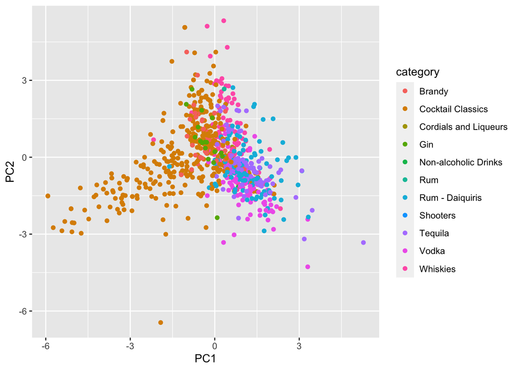

```r
juice(drinks_pca) %>%
  ggplot(aes(PC1,PC2)) +
  geom_point(aes(color = category))
```

Qué porcentaje de la varianza están capturando cada uno de los componentes?

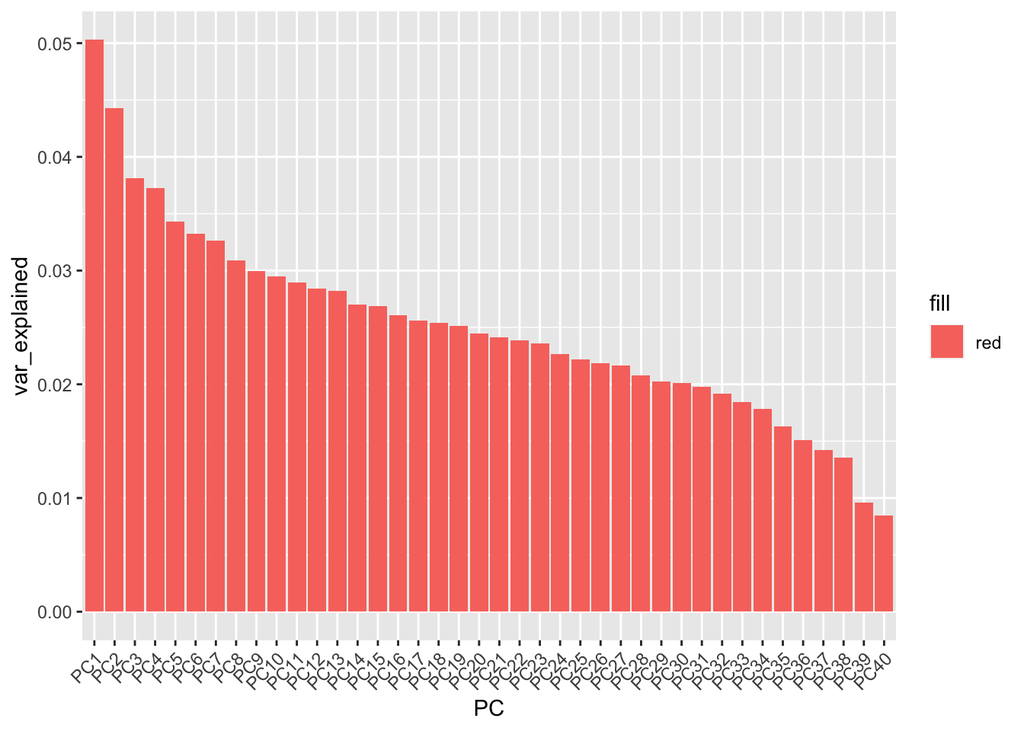

```r
sd <- drinks_pca$steps[[2]]$res$sdev
percent_variation <- sd^2 / sum(sd^2)
var_df <- data.frame(PC=paste0("PC",1:length(sd)),
                     var_explained=percent_variation,
                     stringsAsFactors = FALSE)
var_df %>%
  mutate(PC = fct_inorder(PC)) %>%
  ggplot(aes(x=PC,y=var_explained))+geom_col(aes(fill = "red")) +
  theme(axis.text.x = element_text(angle = 45, hjust = 1))
```

Qué estan capturando cada uno de los componentes principales?

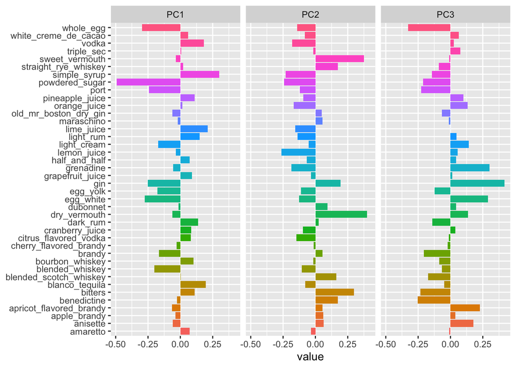

```r
tidy_pca <- tidy(drinks_pca, 2)

tidy_pca %>%
  filter(component %in% paste0("PC", 1:3)) %>%
  mutate(component = fct_inorder(component)) %>%
  ggplot(aes(value, terms, fill = terms)) +
  geom_col(show.legend = FALSE) +
  facet_wrap(~component, nrow = 1) +
  labs(y = NULL)
```

La gráfica anterior nos ayuda a visualizar que ingredientes estan contribuyendo más a cada uno de los componenetes. Por ejemplo en PC1 vemos que es positivo para syrup pero negativo para azúcar. Podemos ver que PC1 captura bebidas con huevo $+$ azúcar $+$ gin vs tequila $+$ limón $+$ syrup.